# Microsoft Corporation

FIAP - Conclusão de Disciplina | 30/11/2016

## A Empresa

## A Microsoft

Microsoft Corporation (NASDAQ: MSFT) é uma empresa americana com sede em Redmond, Washington, fundada por Bill Gates e Paul Allen em 4 de abril de 1975, atualmente presidida por Satya Nadella.

- À esquerda: Paul Allen e Bill Gates.
- À direita: O CEO Satya Nadella

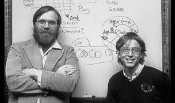

[figure not shown]

## Software

Entre seus produtos de software mais conhecidos estão as linhas de sistemas operacionais Windows, a linha de aplicativos para escritório Office e o navegador Internet Explorer.

É a maior produtora de softwares do mundo por faturamento, e uma das empresas mais valiosas do mundo.

[figure not shown]

[figure not shown]

[figure not shown]

## Hardware

Entre seus principais produtos de hardware estão os consoles de videogame Xbox, a série de tablets Surface e os Smartphones Microsoft Lumia, antiga Nokia.

[figure not shown]

[figure not shown]

[figure not shown]

## Mercado Financeiro

## IPO NASDAQ

Em 1986 a Microsoft fez uma oferta pública de ações na bolsa NASDAQ, com o preço de US$21,00 por ação. No fim do dia cada papel valia US$27,00.

Em Janeiro de 2003, pela primeira vez, a Microsoft ofereceu dividendos pelos seus papéis.

Entre 1986 e 2016 a empresa fez diversos **splits** no preço das ações, que podem ser vistos como mudanças bruscas no preço.

## Histórico de Splits (1/2)

| Data | Taxa |
| --- | --- |
| 21/09/1987 | 2 por 1 |
| 16/04/1990 | 2 por 1 |
| 27/06/1991 | 3 por 2 |
| 15/06/1992 | 3 por 2 |
| 23/05/1994 | 2 por 1 |

## Histórico de Splits (2/2)

| Data | Taxa |
| --- | --- |
| 09/12/1996 | 2 por 1 |
| 23/02/1998 | 2 por 1 |
| 29/03/1999 | 2 por 1 |
| 18/02/2003 | 2 por 1 |

## Valor Ajustado

Devido aos muitos splits que ocorreram, utilizaremos o valor de **fechamento ajustado** ao invés do simples valor de fechamento.

## Histórico de Preços

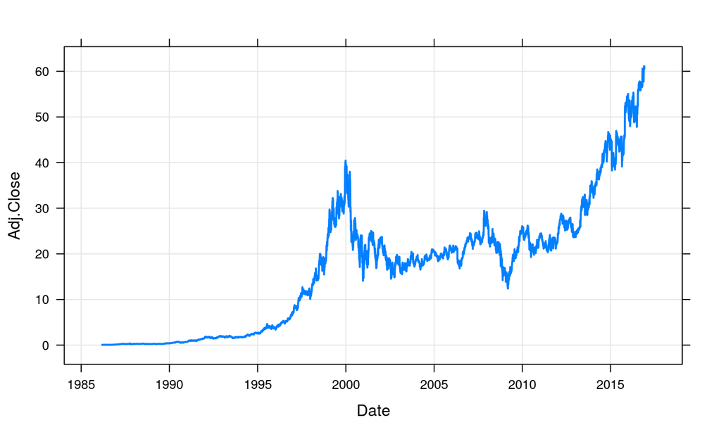

## Histórico de Vendas (concentração)

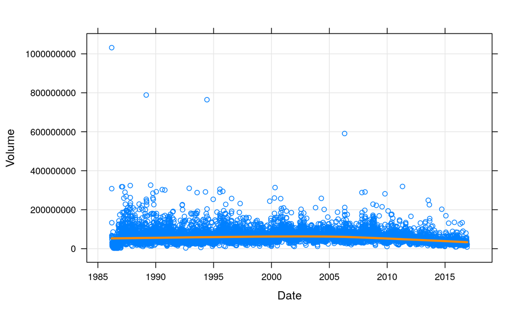

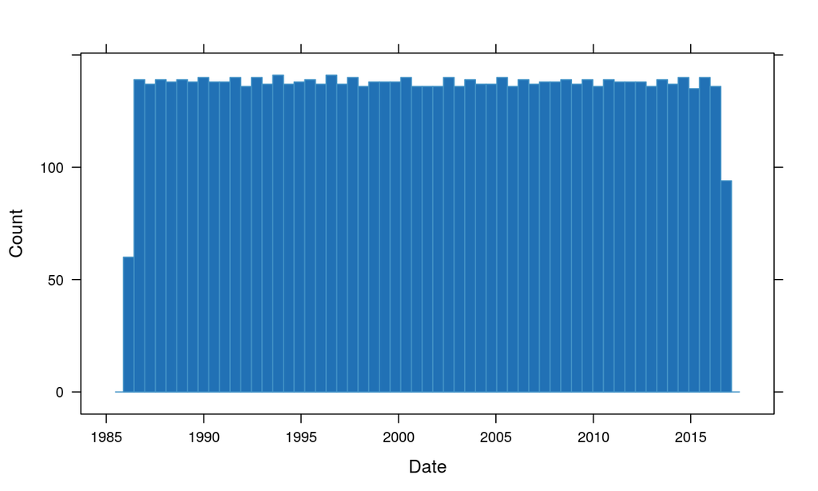

## Eventos Importantes

## A Era Bill Gates

Durante muitos anos Bill Gates comandou a empresa com inovação, motivação e visão, mas no meio de 2008 o bilionário decidiu sair da empresa para se dedicar às suas causas filantrópicas.

Podemos observar que houve uma ondulação no gráfico de preços, com uma queda no preço das ações e uma grande quantidade de vendas na data do anúncio.

## A Era Bill Gates

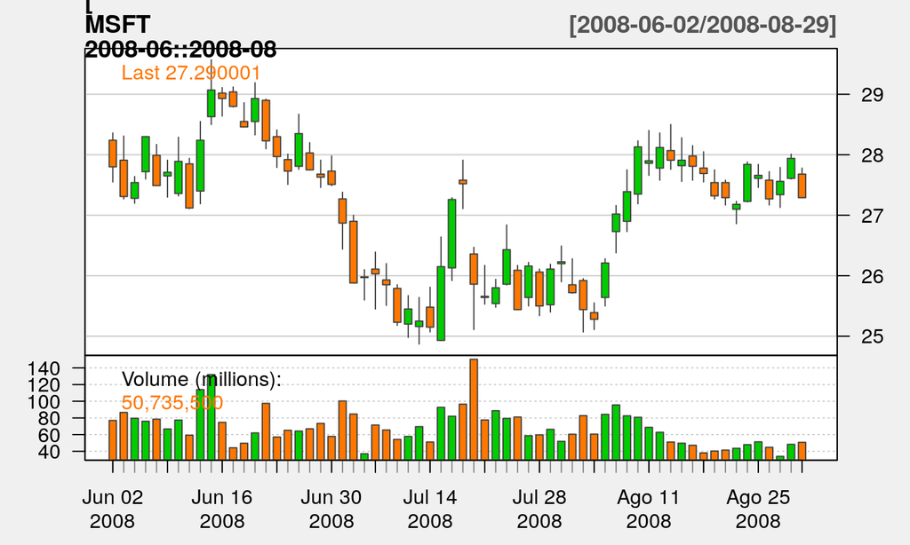

## Era Steve Ballmer

Gates foi substituído por Balmer em 2000 como CEO, mas continuou a comandar a mesa diretora e a dar a visão tecnológica da empresa. Em 2008, entretanto, com a saída de Gates da empresa, Ballmer teve espaço para colocar em prática suas próprias ideias.

## A Era Steve Ballmer

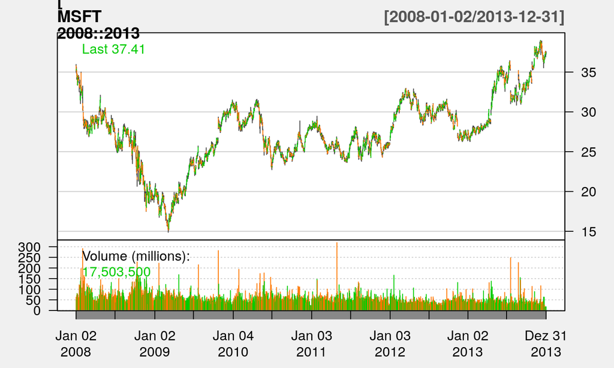

## A Era Satya Nadella

Desde que o indiano assumiu como CEO da Microsoft, o preço das ações se projetou em uma diagonal ascendente. A empresa retomou o posto entre as marcas mais valiosas, e voltou a aparecer em setores de inovação em Cloud, Big Data e Inteligência Artificial.

## A Era Satya Nadella

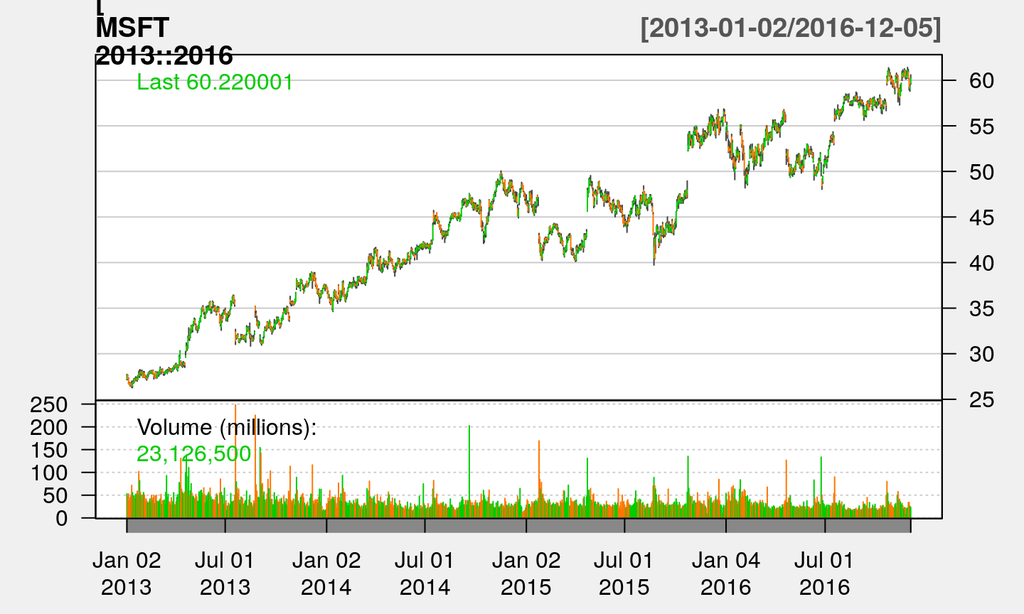

## 2016

Este ano foi particularmente bom para a empresa. Avanços nas áreas de Cloud, de ferramentas de desenvolvimento, de Big Data e de aquisições fizeram as ações se valorizar consideravelmente.

A postura de Satya Nadella é mais aberta ao open source, colaboração e P&D. Com isso, a empresa conseguiu atingir um público diferente do que vinha atingindo.

## 2016

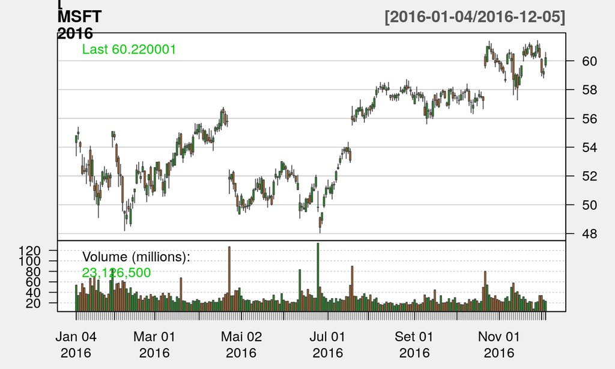

## Previsões para 2017

## Previsões para 2017

Analisando os gráficos com os resultados dos últimos 3 anos, podemos perceber uma clara tendência de alta nos preços das ações.

## 2017 - Ajuste de Regressão Polinomial Local

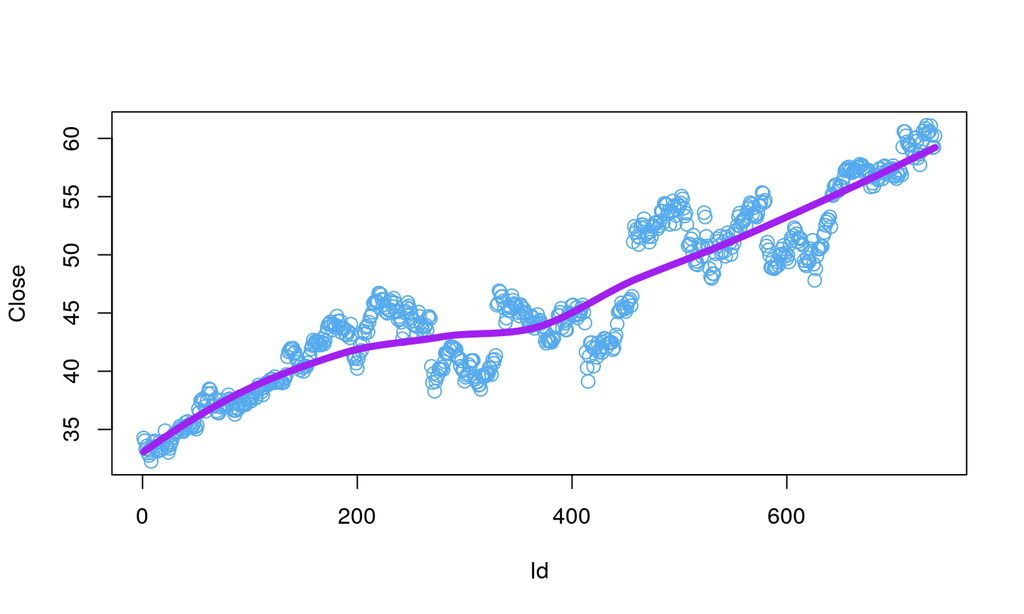

## 2017 - Regressão Linear

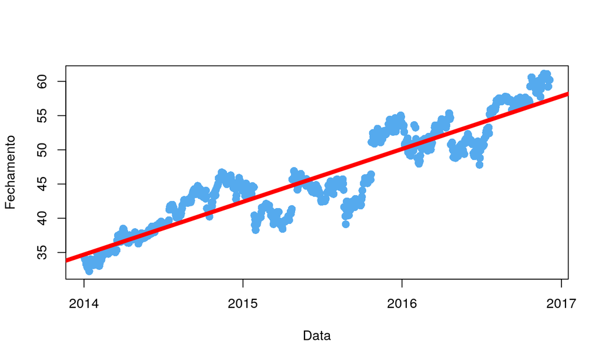

## Referências

- https://pt.wikipedia.org/wiki/Microsoft.
- https://en.wikipedia.org/wiki/Microsoft
- https://www.microsoft.com/en-us/Investor/company-overview.aspx
- http://www.nasdaq.com/symbol/msft
- http://money.cnn.com/quote/quote.html?symb=MSFT
- https://www.stocksplithistory.com/microsoft/